```python
from datetime import datetime

import numpy as np
import pandas as pd

from course_lib.Base.Evaluation.Evaluator import EvaluatorHoldout
from src.data_management.New_DataSplitter_leave_k_out import New_DataSplitter_leave_k_out
from src.data_management.RecSys2019Reader import RecSys2019Reader
from src.data_management.data_reader import get_ICM_train, get_UCM_train
from src.model.Ensemble.Boosting.boosting_preprocessing import add_label
from src.tuning.run_xgboost_tuning import run_xgb_tuning
from src.utils.general_utility_functions import get_split_seed
import matplotlib.pyplot as plt
from src.model import new_best_models
import xgboost as xgb
from xgboost import plot_importance

def _preprocess_dataframe(df: pd.DataFrame):
    df = df.copy()
    df = df.drop(columns=["index"], inplace=False)
    df = df.sort_values(by="user_id", ascending=True)
    df = df.reset_index()
    df = df.drop(columns=["index"], inplace=False)
    return df
```

# Data reading

```python
# Data loading
root_data_path = "../data/"
data_reader = RecSys2019Reader(root_data_path)
data_reader = New_DataSplitter_leave_k_out(data_reader, k_out_value=3, use_validation_set=False,
                                           force_new_split=True, seed=get_split_seed())
data_reader.load_data()
URM_train, URM_test = data_reader.get_holdout_split()

# Build ICMs
ICM_all = get_ICM_train(data_reader)

# Build UCMs: do not change the order of ICMs and UCMs
UCM_all = get_UCM_train(data_reader)

# Reading the dataframe
dataframe_path = "../boosting_dataframe/"
train_df = pd.read_csv(dataframe_path + "train_df_20.csv")
valid_df = pd.read_csv(dataframe_path + "valid_df_20.csv")

train_df = _preprocess_dataframe(train_df)
valid_df = _preprocess_dataframe(valid_df)

print("Retrieving training labels...", end="")
y_train, non_zero_count, total = add_label(data_frame=train_df, URM_train=URM_train)
print("Done")

train_df['label'] = y_train
```

```
NewDataSplitter_leave_k_out: Cold users not allowed
NewDataSplitter_leave_k_out: Reading from original files...
RecSys2019Reader: WARNING --> There is no verification in the consistency of UCMs
DataReader: Verifying data consistency...
DataReader: Verifying data consistency... Passed!
DataReader: current dataset is: <class 'src.data_management.RecSys2019Reader.RecSys2019Reader'>
	Number of items: 18495
	Number of users: 27255
	Number of interactions in URM_all: 398636
	Interaction density: 7.91E-04
	Interactions per user:
		 Min: 1.00E+00
		 Avg: 1.46E+01
		 Max: 6.77E+02
	Interactions per item:
		 Min: 0.00E+00
		 Avg: 2.16E+01
		 Max: 8.99E+02
	Gini Index: 0.54

NewDataSplitter_leave_k_out: Removing 6512 (23.89 %) of 27255 users because they have less than the 4 interactions required for 2 splits (3 for test [and validation if requested] +1 for train)
Warning: 4556 (21.96 %) of 20743 users have no Train items
NewDataSplitter_leave_k_out: Split complete
NewDataSplitter_leave_k_out: Reading from original files...Done
NewDataSplitter_leave_k_out: DataReader: data
	Num items: 18495
	Num users: 20743
	Train 		interactions 266980, 	density 6.96E-04
	Test 		interactions 62229, 	density 1.62E-04



	ICM name: ICM_all, Num features: 1908, feature occurrences: 70755, density 2.01E-03
	ICM name: ICM_price, Num features: 1, feature occurrences: 18493, density 1.00E+00
	ICM name: ICM_asset, Num features: 1, feature occurrences: 18490, density 1.00E+00
	ICM name: ICM_sub_class, Num features: 1905, feature occurrences: 18495, density 5.25E-04
	ICM name: ICM_item_pop, Num features: 1, feature occurrences: 15277, density 8.26E-01


NewDataSplitter_leave_k_out: Done.
```

[output cut: 53 more lines]

[output not shown]

```python
print("Retrieving training labels...", end="")
y_train_valid, non_zero_count_vaid, total_valid = add_label(data_frame=valid_df, URM_train=URM_test)
print("Done")
valid_df['label'] = y_train_valid
```

[output not shown]

[output cut: 53 more lines]

### Pure scores exploration

```python
def plot_score_distribution(column_name):
    # Let's check train and validation performances, minmaxstandardized
    train_mxd = train_df[column_name].values
    valid_mxd = valid_df[column_name].values

    # Sort them
    train_mxd = np.sort(train_mxd)
    valid_mxd = np.sort(valid_mxd)

    # Plot the distributions
    plt.title('Distributions of {} scores between the two datasets'.format(column_name))
    plt.xlabel('(user, item) index')
    plt.ylabel('Score')
    plt.plot(train_mxd, label="Training")
    plt.plot(valid_mxd, label="Validation")
    plt.legend()
    plt.show()
```

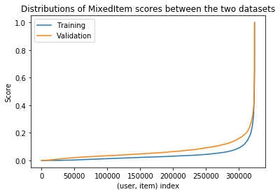

```python
plot_score_distribution("MixedItem")
```

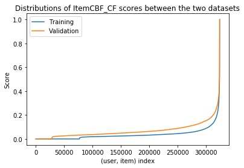

```python
plot_score_distribution("ItemCBF_CF")
```

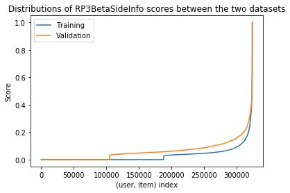

```python
plot_score_distribution("RP3BetaSideInfo")
```

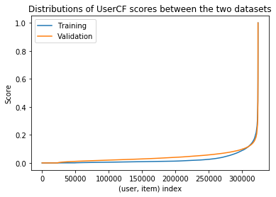

```python
plot_score_distribution("UserCF")
```

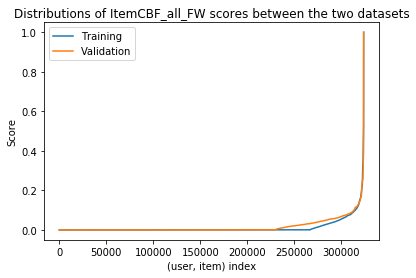

```python
plot_score_distribution("ItemCBF_all_FW")
```

As we can see, the "Validation" curve is always a bit above. This is due to how data has been generated: indeed, for training we keep the scores of the one with the highest score, removing the unseen with low score. Therefore, for many users, the one with few ratings, we remove many unseen items that are likely to be recommended.

```python
def plot_score_distribution_unsorted(column_name_list, train=True):
    # Let's check train and validation performances, minmaxstandardized
    if train:
        df = train_df
    else:
        df = valid_df

    # Plot the distributions
    plt.title("Distribution of scores unsorted")
    plt.xlabel('(user, item) index')
    plt.ylabel('Score')
    for name in column_name_list:
        plt.plot(df[name].values, label=name)
    plt.legend()
    plt.show()
```

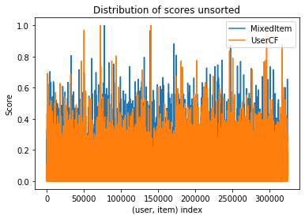

```python
name_list = ["MixedItem", "UserCF"]
plot_score_distribution_unsorted(name_list)
```

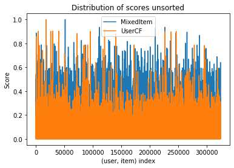

```python
plot_score_distribution_unsorted(name_list, train=False)
```

### Scores mixed label exploration

```python
# Power users exploration
power_users_mask = np.ediff1d(URM_train.tocsr().indptr) > 40
power_users = np.arange(URM_train.shape[0])[power_users_mask]

rare_users = np.ediff1d(URM_train.tocsr().indptr) < 7
rare_users = np.arange(URM_train.shape[0])[rare_users]

extreme_users_mask = np.ediff1d(URM_train.tocsr().indptr) > 100
extreme_users = np.arange(URM_train.shape[0])[extreme_users_mask]

extreme_train_df = train_df[train_df['user_id'].isin(extreme_users)]
extreme_valid_df = valid_df[valid_df['user_id'].isin(extreme_users)]

power_users_not_extreme = np.in1d(power_users, extreme_users, invert=True)
power_users_not_extreme = power_users[power_users_not_extreme]

total_users = np.arange(URM_train.shape[0])
middle_users =  np.in1d(total_users, np.unique(np.concatenate((power_users, rare_users))), invert=True)
middle_users = total_users[middle_users]

power_train_df = train_df[train_df['user_id'].isin(power_users)]
power_valid_df = valid_df[valid_df['user_id'].isin(power_users)]

rare_train_df = train_df[train_df['user_id'].isin(rare_users)]
rare_valid_df = valid_df[valid_df['user_id'].isin(rare_users)]

middle_train_df = train_df[train_df['user_id'].isin(middle_users)]
middle_valid_df = valid_df[valid_df['user_id'].isin(middle_users)]

power_users_not_extreme_train_df = train_df[train_df['user_id'].isin(power_users_not_extreme)]
power_users_not_extreme_valid_df = valid_df[valid_df['user_id'].isin(power_users_not_extreme)]
```

```python
power_train_df['label'].mean()
```

```
0.5684118060435699
```

```python
train_df['label'].mean()
```

```
0.21466917897077903
```

```python
rare_train_df['label'].mean()
```

```
0.062377091599102985
```

```python
valid_df['label'].mean()
```

```
0.014406622598381416
```

```python
power_valid_df['label'].mean()
```

```
0.014862965565706255
```

```python
rare_valid_df['label'].mean()
```

```
0.010738312920476108
```

```python
middle_valid_df['label'].mean()
```

```
0.016705698672911787
```

```python
middle_train_df['label'].mean()
```

```
0.2569867291178767
```

As we can see, there is no such a big difference between middle users and power users, in terms of mean of training labels that are present, in the validation set. Let's see if this is true even for the users with much ratings.

```python
extreme_users_mask = np.ediff1d(URM_train.tocsr().indptr) > 100
extreme_users = np.arange(URM_train.shape[0])[extreme_users_mask]

extreme_train_df = train_df[train_df['user_id'].isin(extreme_users)]
extreme_valid_df = valid_df[valid_df['user_id'].isin(extreme_users)]
```

```python
extreme_train_df['label'].mean()
```

```
0.7961206896551725
```

```python
extreme_valid_df['label'].mean()
```

```
0.010775862068965518
```

Here we can notice that here we have something like an extreme situation: many 1 in train, and many 0s in test: the classifier may learn to predict only 1 when there are "large" user activities and 80% of predictions will be correct: moreover, remember also the unbalance you are giving to the loss function: miss-classifying 1s costs a lot! Let's try to split things in group, and try to plot some graphics. Let's make some trial.

```python
boosting = new_best_models.Boosting.get_model(URM_train=URM_train, train_df=train_df, y_train=y_train,
                                                  valid_df=valid_df,
                                                  model_path="../report/hp_tuning/boosting/Dec15_12-21"
                                                             "-30_k_out_value_3_eval/best_model3")

boosting.RECOMMENDER_NAME = "BOOSTING"
```

```
Recommender_Base_Class: URM Detected 4556 (21.96 %) cold users.
Recommender_Base_Class: URM Detected 4067 (21.99 %) cold items.
```

```python
extreme_users[0:10]
```

```
array([  38,  205,  482,  557,  593,  762,  777,  822,  893, 1072])
```

```python
user_38_valid_df = valid_df[valid_df['user_id']==38]
user_38_valid_df = user_38_valid_df.drop(columns=['user_id', 'item_id', 'label'], inplace=False)
boosting.bst.predict(xgb.DMatrix(user_38_valid_df))
```

```
array([0.9988953 , 0.9990896 , 0.99875104, 0.99993336, 0.99996805,
       0.9999186 , 0.9999614 , 0.999902  , 0.9999316 , 0.9999958 ,
       0.9997104 , 0.99965894, 0.9996855 , 0.99995923, 0.99984443,
       0.9992417 , 0.99974674, 0.9997913 , 0.99366015, 0.9964483 ],
      dtype=float32)
```

Indeed, that is exactly what is happening: the re-ranking might not working well for these users. Let's see if this is true for all the extreme users.

```python
mean_extreme = []
for user in extreme_users:
    curr_user_valid_df = valid_df[valid_df['user_id']==user].copy()
    curr_user_valid_df = curr_user_valid_df.drop(columns=['user_id', 'item_id', 'label'], inplace=False)
    res = boosting.bst.predict(xgb.DMatrix(curr_user_valid_df))
    mean_extreme.append(res.mean())
    print("User {}: media {} - std {} - activity {}".format(user, res.mean(), res.std(), URM_train[user].indices.size))
```

```
User 38: media 0.9992047548294067 - std 0.0014966977760195732 - activity 671
User 205: media 0.9985510110855103 - std 0.0039378805086016655 - activity 121
User 482: media 0.9362766146659851 - std 0.1812870353460312 - activity 196
User 557: media 0.9862722158432007 - std 0.027174891903996468 - activity 178
User 593: media 0.9994293451309204 - std 0.000960686185862869 - activity 158
User 762: media 0.9979852437973022 - std 0.0059301950968801975 - activity 101
User 777: media 0.7752571105957031 - std 0.3007839024066925 - activity 110
User 822: media 0.5807734727859497 - std 0.40046703815460205 - activity 150
User 893: media 0.9904629588127136 - std 0.024724354967474937 - activity 125
User 1072: media 0.8237067461013794 - std 0.2903895080089569 - activity 127
User 1092: media 0.9997045397758484 - std 0.0009269144502468407 - activity 124
User 1515: media 0.9963701963424683 - std 0.009285084903240204 - activity 107
User 1650: media 0.9804977178573608 - std 0.057584214955568314 - activity 147
User 1774: media 0.9617053270339966 - std 0.11116764694452286 - activity 138
User 1987: media 0.9999555349349976 - std 7.174217898864299e-05 - activity 264
User 2011: media 0.8388785123825073 - std 0.25268319249153137 - activity 110
User 2037: media 0.9289323687553406 - std 0.1986915022134781 - activity 102
User 2684: media 0.9893269538879395 - std 0.04625695198774338 - activity 280
User 2748: media 0.7746669054031372 - std 0.26519933342933655 - activity 120
User 2778: media 0.6667250990867615 - std 0.33063310384750366 - activity 117
User 3199: media 0.9967290759086609 - std 0.007566789630800486 - activity 127
User 3302: media 0.9979737997055054 - std 0.00391663471236825 - activity 170
User 3757: media 0.9990304112434387 - std 0.0019722646102309227 - activity 101
User 3777: media 0.9994942545890808 - std 0.0013001662446185946 - activity 110
User 3809: media 0.9990975260734558 - std 0.0016285976162180305 - activity 115
User 3935: media 0.9540258646011353 - std 0.12110134959220886 - activity 129
User 4093: media 0.7873026132583618 - std 0.32225871086120605 - activity 150
User 4227: media 0.6666466593742371 - std 0.34513723850250244 - activity 110
User 4271: media 0.9983188509941101 - std 0.004303394351154566 - activity 106
User 4324: media 0.6911455392837524 - std 0.26998743414878845 - activity 108
User 4706: media 0.8497066497802734 - std 0.2659798860549927 - activity 123
User 5171: media 0.9912089109420776 - std 0.01972511038184166 - activity 214
User 5254: media 0.9905986785888672 - std 0.024525856599211693 - activity 162
User 5430: media 0.9999454617500305 - std 0.00017107119492720813 - activity 122
User 5612: media 0.9816991686820984 - std 0.038594622164964676 - activity 141
User 5620: media 0.9999726414680481 - std 3.1823310564504936e-05 - activity 144
User 5712: media 0.90667325258255 - std 0.18334682285785675 - activity 163
User 5840: media 0.8636052012443542 - std 0.2589344382286072 - activity 134
User 6355: media 0.9173844456672668 - std 0.16366395354270935 - activity 103
User 6445: media 0.9994605779647827 - std 0.0011175237596035004 - activity 118
```

[output cut: 61 more lines]

```
User 17091: media 0.9938039779663086 - std 0.026266098022460938 - activity 138
User 17161: media 0.9996177554130554 - std 0.0003964178031310439 - activity 275
User 17317: media 0.9820804595947266 - std 0.03184650093317032 - activity 125
User 17803: media 0.5067568421363831 - std 0.36269837617874146 - activity 103
User 17813: media 0.9908854365348816 - std 0.02282712422311306 - activity 103
User 18036: media 0.999904990196228 - std 0.00026621995493769646 - activity 113
User 18577: media 0.9329516291618347 - std 0.1100684404373169 - activity 125
User 18791: media 0.9948026537895203 - std 0.01818964071571827 - activity 159
User 18893: media 0.9992915987968445 - std 0.002346952212974429 - activity 498
User 18894: media 0.999186635017395 - std 0.0017417861381545663 - activity 449
User 18914: media 0.999852180480957 - std 0.0001767627545632422 - activity 448
User 19368: media 0.9938047528266907 - std 0.019259413704276085 - activity 238
User 19375: media 0.9995113611221313 - std 0.0016942010261118412 - activity 126
User 19641: media 0.9263797998428345 - std 0.2077600210905075 - activity 112
User 20742: media 0.999341607093811 - std 0.002081578131765127 - activity 250
```

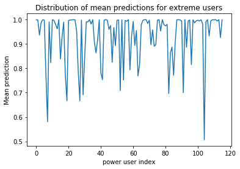

```python
plt.title("Distribution of mean predictions for extreme users")
plt.xlabel('power user index')
plt.ylabel('Mean prediction')
plt.plot(mean_extreme)
plt.show()
```

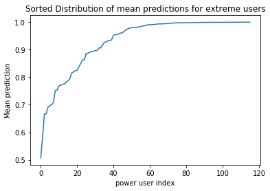

```python
plt.title("Sorted Distribution of mean predictions for extreme users")
plt.xlabel('power user index')
plt.ylabel('Mean prediction')
plt.plot(np.sort(np.array(mean_extreme)))
plt.show()
```

As we can see, 0s and 1s are not learnt correctly, since many of the average label for them is 0.01, while here we are getting 0.9: it is not learning the right things. How can we solve this issue, without introducing data leakage? We have to re-think the way the dataset is generated. Let's check if also for middle users we have this behavior.

```python
mean_middle = []
for user in middle_users:
    curr_user_valid_df = valid_df[valid_df['user_id']==user].copy()
    curr_user_valid_df = curr_user_valid_df.drop(columns=['user_id', 'item_id', 'label'], inplace=False)
    res = boosting.bst.predict(xgb.DMatrix(curr_user_valid_df))
    mean_middle.append(res.mean())
```

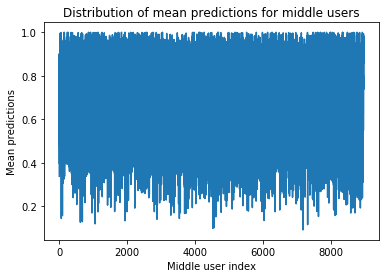

```python
plt.title("Distribution of mean predictions for middle users")
plt.xlabel('Middle user index')
plt.ylabel('Mean predictions')
plt.plot(mean_middle)
plt.show()
```

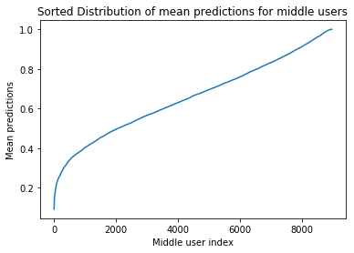

```python
plt.title("Sorted Distribution of mean predictions for middle users")
plt.xlabel('Middle user index')
plt.ylabel('Mean predictions')
plt.plot(np.sort(np.array(mean_middle)))
plt.show()
```

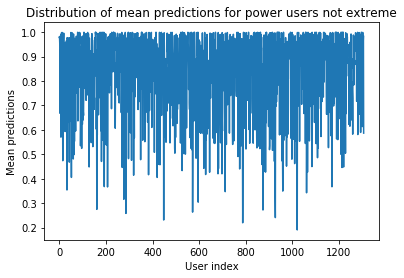

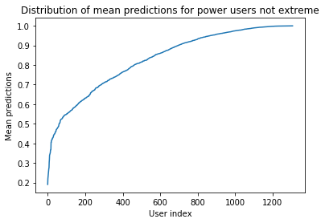

```python
power_users_not_extreme = np.in1d(power_users, extreme_users, invert=True)
power_users_not_extreme = power_users[power_users_not_extreme]

mean_power_not_extreme = []
for user in power_users_not_extreme:
    curr_user_valid_df = valid_df[valid_df['user_id']==user].copy()
    curr_user_valid_df = curr_user_valid_df.drop(columns=['user_id', 'item_id', 'label'], inplace=False)
    res = boosting.bst.predict(xgb.DMatrix(curr_user_valid_df))
    mean_power_not_extreme.append(res.mean())

plt.title("Distribution of mean predictions for power users not extreme")
plt.xlabel('User index')
plt.ylabel('Mean predictions')
plt.plot(mean_power_not_extreme)
plt.show()

plt.title("Distribution of mean predictions for power users not extreme")
plt.xlabel('User index')
plt.ylabel('Mean predictions')
plt.plot(np.sort(np.array(mean_power_not_extreme)))
plt.show()
```

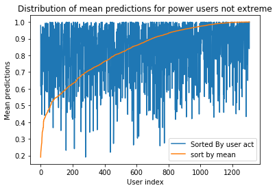

```python
# Let's try to do this last step, sorting user due to their user activity profile
act_pune = URM_train[power_users_not_extreme].sum(axis=1)
act_pune = np.argsort(np.array(act_pune).squeeze())
power_users_not_extreme = power_users_not_extreme[act_pune]

mean_power_not_extreme_sorted = []
for user in power_users_not_extreme:
    curr_user_valid_df = valid_df[valid_df['user_id']==user].copy()
    curr_user_valid_df = curr_user_valid_df.drop(columns=['user_id', 'item_id', 'label'], inplace=False)
    res = boosting.bst.predict(xgb.DMatrix(curr_user_valid_df))
    mean_power_not_extreme_sorted.append(res.mean())

plt.title("Distribution of mean predictions for power users not extreme")
plt.xlabel('User index')
plt.ylabel('Mean predictions')
plt.plot(mean_power_not_extreme_sorted, label="Sorted By user act")
plt.plot(np.sort(np.array(mean_power_not_extreme)), label="sort by mean")
plt.legend()
plt.show()
```

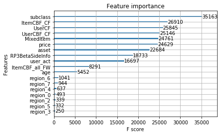

```python
plot_importance(boosting.bst)
```

In order to trouble shoot this, let's better inspect the behavior for the middle users. Which users has such an high mean precitions? Let's say above 0.8

```python
middle_high_mean = []
t = 0.8
for user in middle_users:
    curr_user_valid_df = valid_df[valid_df['user_id']==user].copy()
    curr_user_valid_df = curr_user_valid_df.drop(columns=['user_id', 'item_id', 'label'], inplace=False)
    res = boosting.bst.predict(xgb.DMatrix(curr_user_valid_df))
    if res.mean() > 0.8:
        middle_high_mean.append(user)
```

```python
middle_users.size
```

```
8967
```

```python
middle_high_mean = np.array(middle_high_mean)
middle_high_mean.size
```

```
2403
```

For many of them we have such high behaviours...

```python
middle_high_df_valid = valid_df[valid_df['user_id'].isin(middle_high_mean)]
middle_high_df_train = train_df[train_df['user_id'].isin(middle_high_mean)]
```

```python
middle_high_df_valid['label'].mean()
```

```
0.023220973782771534
```

```python
middle_high_df_train['label'].mean()
```

```
0.2935705368289638
```

In the training set, we are almost in line with the mean of the training set...

```python
train_df['label'].mean()
```

```
0.21466917897077903
```

```python
middle_high_df_valid['ItemCBF_CF'].mean() # Score seems to be high
```

```
0.10883277823581364
```

```python
middle_valid_df['ItemCBF_CF'].mean()
```

```
0.07733984201216863
```

```python
valid_df['ItemCBF_CF'].mean()
```

```
0.06723813695826711
```

```python
middle_high_df_valid['UserCF'].mean()
```

```
0.06406327621707676
```

```python
valid_df['UserCF'].mean()
```

```
0.041200026447397425
```

```python
middle_high_df_valid['UserCF'].mean()
```

```
0.06406327621707676
```

```python
middle_high_df.describe()
```

|  | user_id | item_id | MixedItem | ItemCBF_CF | RP3BetaSideInfo | UserCBF_CF | ItemCBF_all_FW | UserCF | price | asset | ... | region_0 | region_2 | region_3 | region_4 | region_5 | region_6 | region_7 | age | user_act | label |
| --- | --- | --- | --- | --- | --- | --- | --- | --- | --- | --- | --- | --- | --- | --- | --- | --- | --- | --- | --- | --- | --- |
| count | 48060.000000 | 48060.000000 | 48060.000000 | 48060.000000 | 48060.000000 | 48060.000000 | 48060.000000 | 48060.000000 | 48060.000000 | 48060.000000 | ... | 48060.000000 | 48060.000000 | 48060.000000 | 48060.000000 | 48060.000000 | 48060.000000 | 48060.000000 | 48060.000000 | 48060.00000 | 48060.000000 |
| mean | 9796.605493 | 7665.485248 | 0.111910 | 0.108833 | 0.104313 | 0.138538 | 0.026054 | 0.064063 | 0.004625 | 0.004140 | ... | 0.016646 | 0.022056 | 0.026633 | 0.076987 | 0.042863 | 0.384519 | 0.321265 | 4.647940 | 21.44278 | 0.023221 |
| std | 5969.625700 | 4879.880420 | 0.072759 | 0.068599 | 0.081847 | 0.077365 | 0.046945 | 0.042165 | 0.010913 | 0.009912 | ... | 0.127942 | 0.146866 | 0.161011 | 0.266574 | 0.202550 | 0.486487 | 0.466967 | 2.056057 | 9.15068 | 0.150606 |
| min | 9.000000 | 5.000000 | 0.019659 | 0.000000 | 0.000000 | 0.000000 | 0.000000 | 0.000000 | 0.000047 | 0.000237 | ... | 0.000000 | 0.000000 | 0.000000 | 0.000000 | 0.000000 | 0.000000 | 0.000000 | 1.000000 | 7.00000 | 0.000000 |
| 25% | 4507.000000 | 4361.000000 | 0.067980 | 0.065981 | 0.059087 | 0.084787 | 0.000000 | 0.035198 | 0.001408 | 0.001282 | ... | 0.000000 | 0.000000 | 0.000000 | 0.000000 | 0.000000 | 0.000000 | 0.000000 | 3.000000 | 14.00000 | 0.000000 |
| 50% | 9593.000000 | 6289.000000 | 0.091281 | 0.088173 | 0.084267 | 0.124095 | 0.000000 | 0.054559 | 0.002394 | 0.002137 | ... | 0.000000 | 0.000000 | 0.000000 | 0.000000 | 0.000000 | 0.000000 | 0.000000 | 4.000000 | 21.00000 | 0.000000 |
| 75% | 14869.000000 | 9476.000000 | 0.129650 | 0.128311 | 0.129232 | 0.175556 | 0.042252 | 0.081910 | 0.004272 | 0.003704 | ... | 0.000000 | 0.000000 | 0.000000 | 0.000000 | 0.000000 | 1.000000 | 1.000000 | 6.000000 | 28.00000 | 0.000000 |
| max | 20740.000000 | 18484.000000 | 0.935455 | 0.899513 | 1.000000 | 1.000000 | 1.000000 | 0.637199 | 1.000000 | 1.000000 | ... | 1.000000 | 1.000000 | 1.000000 | 1.000000 | 1.000000 | 1.000000 | 1.000000 | 10.000000 | 40.00000 | 1.000000 |

8 rows × 21 columns

```python
train_df.describe()
```

|  | user_id | item_id | MixedItem | ItemCBF_CF | RP3BetaSideInfo | UserCBF_CF | ItemCBF_all_FW | UserCF | price | asset | ... | region_0 | region_2 | region_3 | region_4 | region_5 | region_6 | region_7 | age | user_act | label |
| --- | --- | --- | --- | --- | --- | --- | --- | --- | --- | --- | --- | --- | --- | --- | --- | --- | --- | --- | --- | --- | --- |
| count | 323740.000000 | 323740.000000 | 323740.000000 | 323740.000000 | 323740.000000 | 323740.000000 | 323740.000000 | 323740.000000 | 323740.000000 | 323740.000000 | ... | 323740.000000 | 323740.000000 | 323740.0000 | 323740.000000 | 323740.000000 | 323740.000000 | 323740.000000 | 323740.000000 | 323740.000000 | 323740.000000 |
| mean | 10145.036820 | 8450.060907 | 0.035703 | 0.035681 | 0.029739 | 0.061765 | 0.011148 | 0.024570 | 0.006701 | 0.005631 | ... | 0.018966 | 0.024155 | 0.0278 | 0.098351 | 0.054674 | 0.355903 | 0.297276 | 4.594181 | 16.493482 | 0.214669 |
| std | 5921.527913 | 4790.777682 | 0.049814 | 0.046283 | 0.055404 | 0.096688 | 0.037765 | 0.043772 | 0.015186 | 0.013349 | ... | 0.136405 | 0.153531 | 0.1644 | 0.297788 | 0.227342 | 0.478787 | 0.457060 | 2.049390 | 21.073533 | 0.410593 |
| min | 0.000000 | 0.000000 | 0.000000 | 0.000000 | 0.000000 | 0.000000 | 0.000000 | 0.000000 | 0.000047 | 0.000095 | ... | 0.000000 | 0.000000 | 0.0000 | 0.000000 | 0.000000 | 0.000000 | 0.000000 | 1.000000 | 1.000000 | 0.000000 |
| 25% | 5059.000000 | 4719.000000 | 0.009683 | 0.014383 | 0.000000 | 0.010979 | 0.000000 | 0.004033 | 0.001925 | 0.001614 | ... | 0.000000 | 0.000000 | 0.0000 | 0.000000 | 0.000000 | 0.000000 | 0.000000 | 3.000000 | 4.000000 | 0.000000 |
| 50% | 10024.000000 | 7602.000000 | 0.023974 | 0.026240 | 0.000000 | 0.023521 | 0.000000 | 0.009119 | 0.003521 | 0.002944 | ... | 0.000000 | 0.000000 | 0.0000 | 0.000000 | 0.000000 | 0.000000 | 0.000000 | 4.000000 | 10.000000 | 0.000000 |
| 75% | 15186.000000 | 12333.000000 | 0.041377 | 0.042266 | 0.043975 | 0.060146 | 0.000000 | 0.022845 | 0.006338 | 0.005223 | ... | 0.000000 | 0.000000 | 0.0000 | 0.000000 | 0.000000 | 1.000000 | 1.000000 | 6.000000 | 21.000000 | 0.000000 |
| max | 20742.000000 | 18494.000000 | 1.000000 | 1.000000 | 1.000000 | 1.000000 | 1.000000 | 1.000000 | 1.000000 | 1.000000 | ... | 1.000000 | 1.000000 | 1.0000 | 1.000000 | 1.000000 | 1.000000 | 1.000000 | 10.000000 | 671.000000 | 1.000000 |

8 rows × 21 columns

```python
valid_df.describe()
```

|  | user_id | item_id | MixedItem | ItemCBF_CF | RP3BetaSideInfo | UserCBF_CF | ItemCBF_all_FW | UserCF | price | asset | ... | region_0 | region_2 | region_3 | region_4 | region_5 | region_6 | region_7 | age | user_act | label |
| --- | --- | --- | --- | --- | --- | --- | --- | --- | --- | --- | --- | --- | --- | --- | --- | --- | --- | --- | --- | --- | --- |
| count | 323740.000000 | 323740.000000 | 323740.000000 | 323740.000000 | 323740.000000 | 323740.000000 | 323740.000000 | 323740.000000 | 323740.000000 | 323740.000000 | ... | 323740.000000 | 323740.000000 | 323740.0000 | 323740.000000 | 323740.000000 | 323740.000000 | 323740.000000 | 323740.000000 | 323740.000000 | 323740.000000 |
| mean | 10145.036820 | 7987.274378 | 0.067654 | 0.067238 | 0.060831 | 0.074814 | 0.015680 | 0.041200 | 0.005751 | 0.004979 | ... | 0.018966 | 0.024155 | 0.0278 | 0.098351 | 0.054674 | 0.355903 | 0.297276 | 4.594181 | 16.493482 | 0.014407 |
| std | 5921.527913 | 4809.897526 | 0.063373 | 0.059807 | 0.069436 | 0.064384 | 0.036712 | 0.039399 | 0.013042 | 0.011595 | ... | 0.136405 | 0.153531 | 0.1644 | 0.297788 | 0.227342 | 0.478787 | 0.457060 | 2.049390 | 21.073533 | 0.119160 |
| min | 0.000000 | 0.000000 | 0.000000 | 0.000000 | 0.000000 | 0.000000 | 0.000000 | 0.000000 | 0.000047 | 0.000095 | ... | 0.000000 | 0.000000 | 0.0000 | 0.000000 | 0.000000 | 0.000000 | 0.000000 | 1.000000 | 1.000000 | 0.000000 |
| 25% | 5059.000000 | 4638.000000 | 0.029263 | 0.032814 | 0.000000 | 0.029532 | 0.000000 | 0.016917 | 0.001690 | 0.001519 | ... | 0.000000 | 0.000000 | 0.0000 | 0.000000 | 0.000000 | 0.000000 | 0.000000 | 3.000000 | 4.000000 | 0.000000 |
| 50% | 10024.000000 | 6798.000000 | 0.050951 | 0.051970 | 0.050658 | 0.057472 | 0.000000 | 0.030894 | 0.003052 | 0.002612 | ... | 0.000000 | 0.000000 | 0.0000 | 0.000000 | 0.000000 | 0.000000 | 0.000000 | 4.000000 | 10.000000 | 0.000000 |
| 75% | 15186.000000 | 10778.000000 | 0.086107 | 0.083663 | 0.081775 | 0.102611 | 0.015587 | 0.054271 | 0.005399 | 0.004558 | ... | 0.000000 | 0.000000 | 0.0000 | 0.000000 | 0.000000 | 1.000000 | 1.000000 | 6.000000 | 21.000000 | 0.000000 |
| max | 20742.000000 | 18494.000000 | 1.000000 | 1.000000 | 1.000000 | 1.000000 | 1.000000 | 1.000000 | 1.000000 | 1.000000 | ... | 1.000000 | 1.000000 | 1.0000 | 1.000000 | 1.000000 | 1.000000 | 1.000000 | 10.000000 | 671.000000 | 1.000000 |

8 rows × 21 columns

Scores in that part seems to be larger... maybe this could be a motivation, but it is still strange. The classifier is not behaving correctly.

## Extreme users exploration

```python
def plot_feature(df_list, column_name, graph_title, label_list, is_group_by=True):
    plt.title(graph_title)
    plt.xlabel('user index')
    plt.ylabel('Score')

    for i, df in enumerate(df_list):
        if is_group_by:
            val = df.groupby('user_id')[column_name].mean().values
        else:
            val = df[column_name].values
        val = np.sort(val)
        plt.plot(val, label=label_list[i])
    plt.legend()
    plt.show()
```

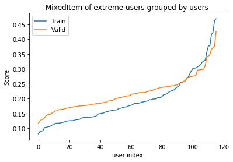

```python
plot_feature([extreme_train_df, extreme_valid_df], 'MixedItem', 'MixedItem of extreme users grouped by users', ['Train', 'Valid'])
```

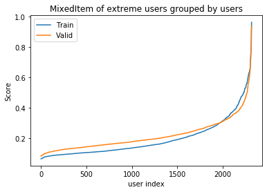

```python
plot_feature([extreme_train_df, extreme_valid_df], 'MixedItem', 'MixedItem of extreme users grouped by users', ['Train', 'Valid'], False)
```

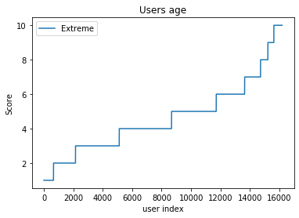

```python
plot_feature([train_df], 'age', 'Users age', ['Extreme', 'All'])
```

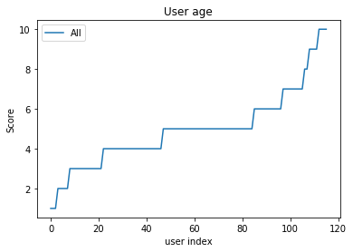

```python
plot_feature([extreme_train_df], 'age', 'User age', ['All'])
```